# Multiple linear regression

# Multiple linear regression: the mathematical framework

## What will we learn in this empirical example ?

1. Estimating a linear regression with multiple variables.
2. Building technical indicators.

## Theory behind the empirical exercise

In this short document, we shall test two trading strategies of chartists on monthly IBM returns.

1. The first strategy is based on simple moving averages (SMA). When two SMA cross, this is a signal to buy or to sell an asset depending on the length of the SMA. Let us denote the simple moving average over the s previous months as MA(s), i.e. $MA(s)_t = \frac{1}{s}\sum_{i=0}^{s-1}P_{t-i}$. If $l>s$ (l=long term and s=short term), the moving average strategy tells us to buy when $MA(l)_t<MA(s)_t$ to benefit from the current upward trend of the asset price. Our technical indicator that captures this buy order is built as follows

   $$S(s,l)_{t} = 1 \text{ if } MA(s)_t>MA(l)_t \text{ and } \text{S(s,l)}_{t} = 0 \text{ otherwise}.$$
   For more information on this trading strategy, see for instance these videos ([video 1](https://www.youtube.com/watch?v=5rMkQurfxrE), [video 2](https://www.youtube.com/watch?v=4R2CDbw4g88)).
2. The second strategy is based on momentum. Intuitively, a current stock price that is higher than its level $l$ periods ago indicates positive momentum and relatively high expected returns. Then, we should buy the asset and benefit from the upward trend. Building this indicator, denoted *Mom(l)*, leads to

   $$\text{Mom(l)}_{t} = 1 \text{ if } P_t\geq P_{t-l} \text{ and } \text{Mom(l)}_{t} = 0 \text{ otherwise}.$$

The two strategies depend on their lag values $s,l$ and $l$, respectively. In this exercise, we shall consider a moving average with $s=2$ and $l=12$ and a momentum strategy with $l=9$. As the code is generic, you can easily test other lag values. The buying (and selling) orders of the two strategies can be correlated so we consider a multiple linear regression to test them jointly. Given monthly returns $y_t$, we will estimate the multiple linear regression,

$$y_t = \beta_1 + \beta_2 S(s,l)_t + \beta_3 \text{Mom}(l)_t + \beta_4 \text{Mom}(l)_t S(s,l)_t + \epsilon_t.$$
The cross-product variable $\text{Mom}(l)S(s,l)$ stands as the strategy of buying the asset when both MA and Momentum strategies give a buying signal. The other coefficients $\beta_2$ and $\beta_3$ can be interpreted as the returns of applying the MA or the Momentum strategy when the two signals diverge.

## From theory to practice

```python
import matplotlib.pyplot as plt
import pandas as pd
import numpy as np
import statsmodels.api as sm
url="https://raw.githubusercontent.com/adufays/GDP_expectancy/main/IBM.csv"
data = pd.read_csv(url,sep=",")

#data = pd.read_excel (r'C:/Users/Helium/Dropbox/ULAVAL/Cours - Essec/Econometrics/Slides/1 - Empirical exercises/SP500_asset_returns.xlsx')
data.head()
```

```
##          Date      Open      High       Low     Close  Adj Close    Volume
## 0  1962-01-01  7.713333  7.713333  7.003334  7.226666   1.779273   8760000
## 1  1962-02-01  7.300000  7.480000  7.093333  7.160000   1.762859   5737600
## 2  1962-03-01  7.186666  7.413333  7.070000  7.103333   1.749143   5344000
## 3  1962-04-01  7.100000  7.100000  6.000000  6.053333   1.490589  12851200
## 4  1962-05-01  6.053333  6.530000  4.733333  5.233333   1.288670  49307200
```

```python
price  = np.array(data.Close)
date = data.Date
fig, ax = plt.subplots(figsize=(10, 10))
plt.plot(date,price)
plt.xticks(date[np.arange(0, np.size(date), 100)])
```

```
## ([<matplotlib.axis.XTick object at 0x0000000034CC8A60>, <matplotlib.axis.XTick object at 0x0000000034CC8A30>, <matplotlib.axis.XTick object at 0x0000000034CBCDF0>, <matplotlib.axis.XTick object at 0x0000000036D19A60>, <matplotlib.axis.XTick object at 0x0000000036D19FA0>, <matplotlib.axis.XTick ob…
```

```python
plt.setp(ax.get_xticklabels(), rotation=45)
```

```
## [None, None, None, None, None, None, None, None, None, None, None, None, None, None, None, None]
```

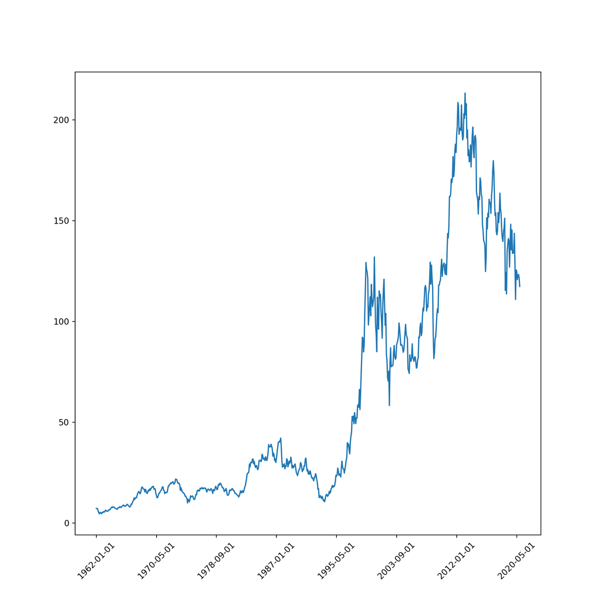

```python
plt.show()
```

We now create a function *MA_strat* that creates simple moving average given a specific lag value. We then use it to plot a long-term and a short-term moving averages. The trading strategy consists in buying the asset when the short-term moving average is above the long-term one. The variable *tech_MA* summarizes this trading strategy.

```python
def MA_strat(price,s):
    T = np.size(price)
    MA = np.zeros([T,1])
    for t in range(s-1,T):
        MA[t] = np.mean(price[(t-s+1):(t+1)])

    return(MA)


MA_long_term = MA_strat(price,12)
MA_short_term = MA_strat(price,2)
tech_MA = MA_short_term>MA_long_term

fig, ax = plt.subplots(figsize=(10, 10))
plt.plot(date,MA_short_term,color="red")
plt.plot(date,MA_long_term,color="blue")
plt.xticks(date[np.arange(0, np.size(date), 100)])
```

```
## ([<matplotlib.axis.XTick object at 0x0000000036D57B80>, <matplotlib.axis.XTick object at 0x0000000036D57CA0>, <matplotlib.axis.XTick object at 0x0000000034CEA700>, <matplotlib.axis.XTick object at 0x0000000037CACD00>, <matplotlib.axis.XTick object at 0x0000000036FB91C0>, <matplotlib.axis.XTick ob…
```

```python
plt.setp(ax.get_xticklabels(), rotation=45)
```

```
## [None, None, None, None, None, None, None, None, None, None, None, None, None, None, None, None]
```

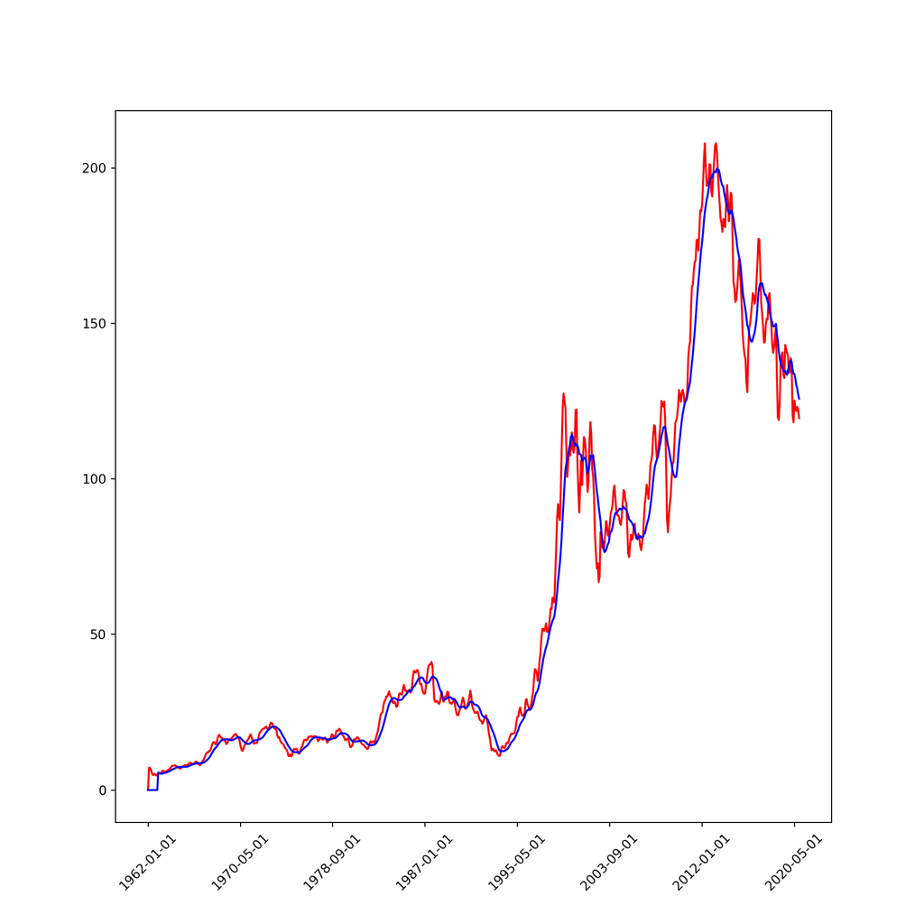

```python
plt.show()
```

We create a function *Momentum* that creates a momentum trading strategy given a specific lag value.

```python
def Momentum(price,s):
    T = np.size(price)
    Mom = np.zeros([T,1])
    for t in range(s,T):
        Mom[t] = price[t]>=price[(t-s)]

    return(Mom)

tech_MOM = Momentum(price,9)
```

We now compute the IBM returns in percentage over time.

```python
T = np.size(price)
IBM_ret = np.zeros([T,1])
IBM_ret[0:(T-1),0] = 100*(price[1:T]-price[0:(T-1)])/price[0:(T-1)]


fig, ax = plt.subplots(figsize=(10, 10))
plt.plot(date,IBM_ret,color="blue")
plt.xticks(date[np.arange(0, np.size(date), 100)])
```

```
## ([<matplotlib.axis.XTick object at 0x0000000036FA6F70>, <matplotlib.axis.XTick object at 0x0000000036FA6F40>, <matplotlib.axis.XTick object at 0x0000000036FA6340>, <matplotlib.axis.XTick object at 0x00000000373E1EE0>, <matplotlib.axis.XTick object at 0x00000000373E53D0>, <matplotlib.axis.XTick ob…
```

```python
plt.setp(ax.get_xticklabels(), rotation=45)
```

```
## [None, None, None, None, None, None, None, None, None, None, None, None, None, None, None, None]
```

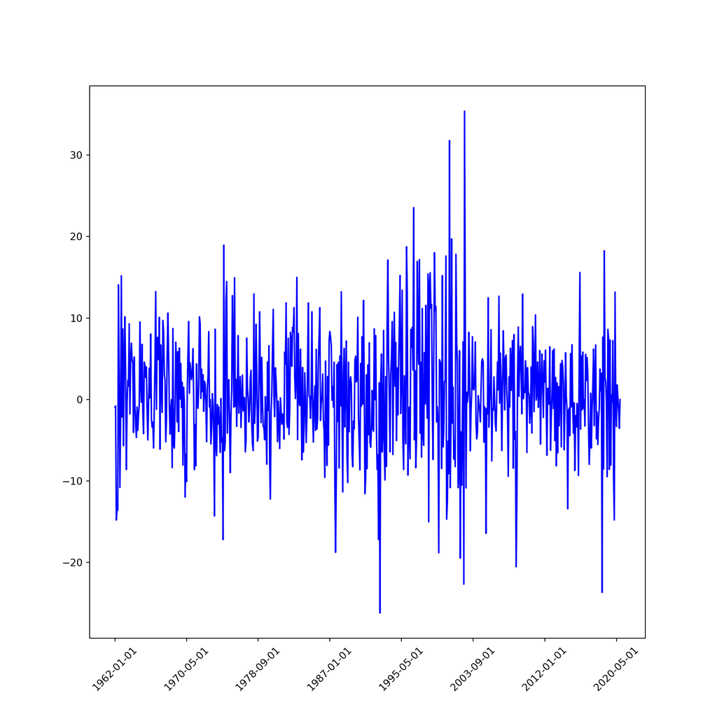

```python
plt.show()
```

Eventually, we can estimate our multiple regression. To do so, we create a matrix of dimension Tx4 with an intercept in the first column and the three trading strategies (the MA and the Mom strategies as well as the joint strategy) for the last three columns. We then apply the OLS formula to get the OLS estimates.

```python
X = np.zeros([T,4])
y = IBM_ret
X[:,0] = 1
X[:,1:4] = np.hstack((tech_MA,tech_MOM,tech_MA*tech_MOM))

XprimeX=np.matmul(np.transpose(X),X)
XprimeXinv=np.linalg.inv(XprimeX)
beta_ols=np.matmul(XprimeXinv,np.matmul(np.transpose(X),y))
print(beta_ols)
```

```
## [[ 0.81560605]
##  [-0.9318349 ]
##  [-0.72443534]
##  [ 1.49896574]]
```

```python
X_mom_MA = X[:,np.asarray((0,3))]
XprimeX=np.matmul(np.transpose(X_mom_MA),X_mom_MA)
XprimeXinv=np.linalg.inv(XprimeX)
beta_ols_mom_MA=np.matmul(XprimeXinv,np.matmul(np.transpose(X_mom_MA),y))
print(beta_ols_mom_MA)
```

```
## [[0.60762112]
##  [0.05068043]]
```